# Exercise for Lecture 4 - Differential expression with the limma package

#### Question 1. Look at the distribution of “true” s.d. (each gene has a different s.d.). You will change this distribution later to see effect on differential detection performance.

```r
max(sd)
```

```
## [1] 14191.59
```

```r
sum(sd>1000)
```

```
## [1] 4
```

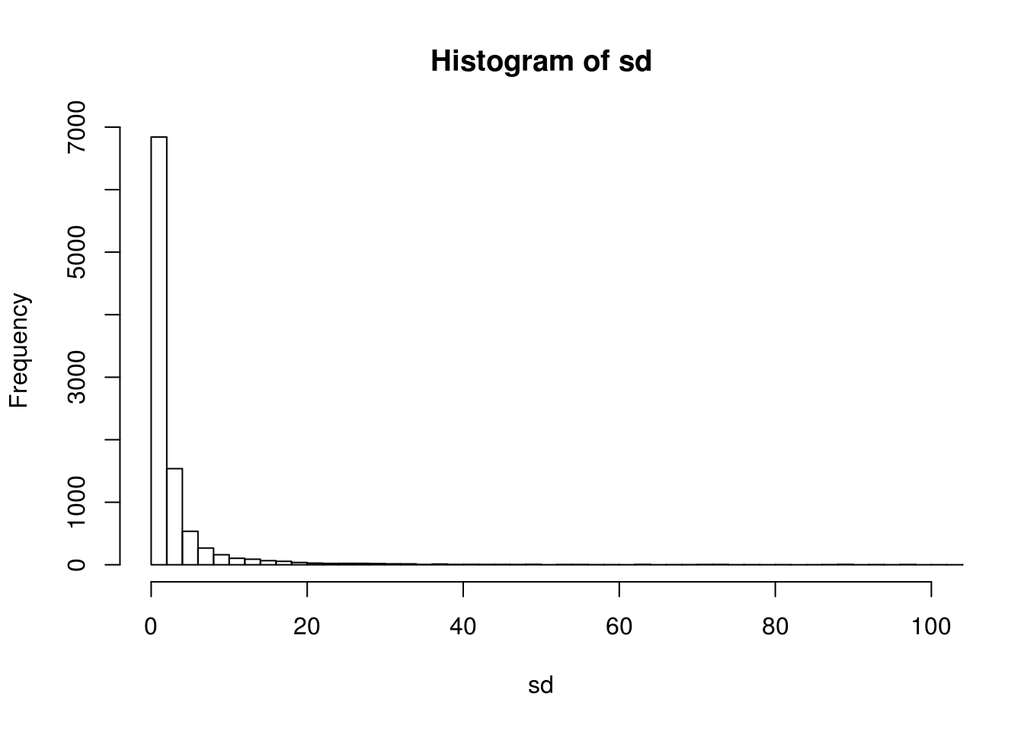

```r
hist(sd, xlim=c(0,100), breaks=10000)
```

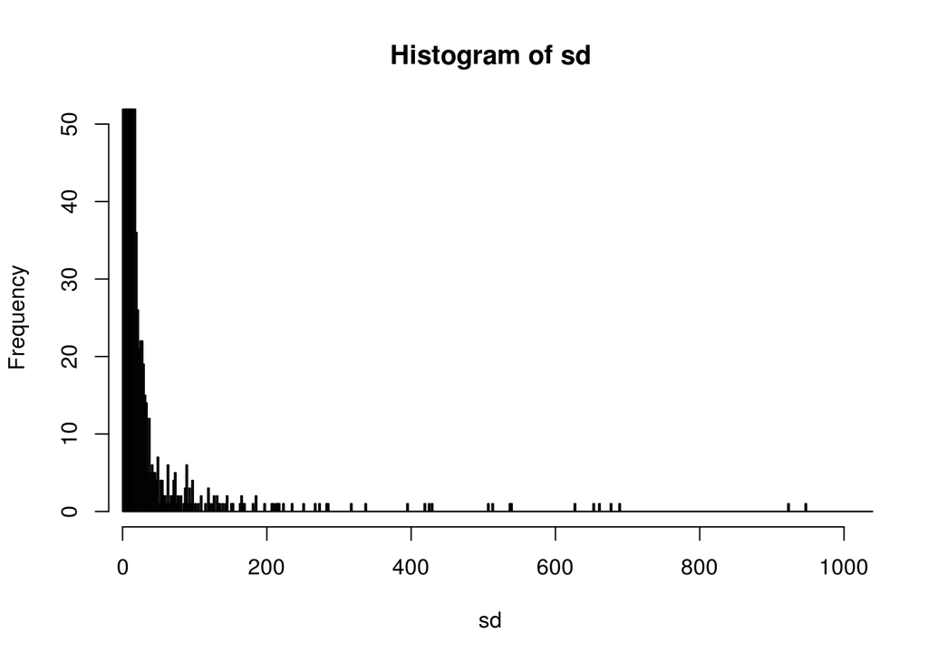

```r
hist(sd, xlim=c(20,1000), breaks=10000, ylim = c(0,50))
```

#### Question 2. To make sure you understand the simulation, look at some of the rows in the table. For example, plot the data (e.g., a barplot) for one of the features that is differential and one that is non-differential.

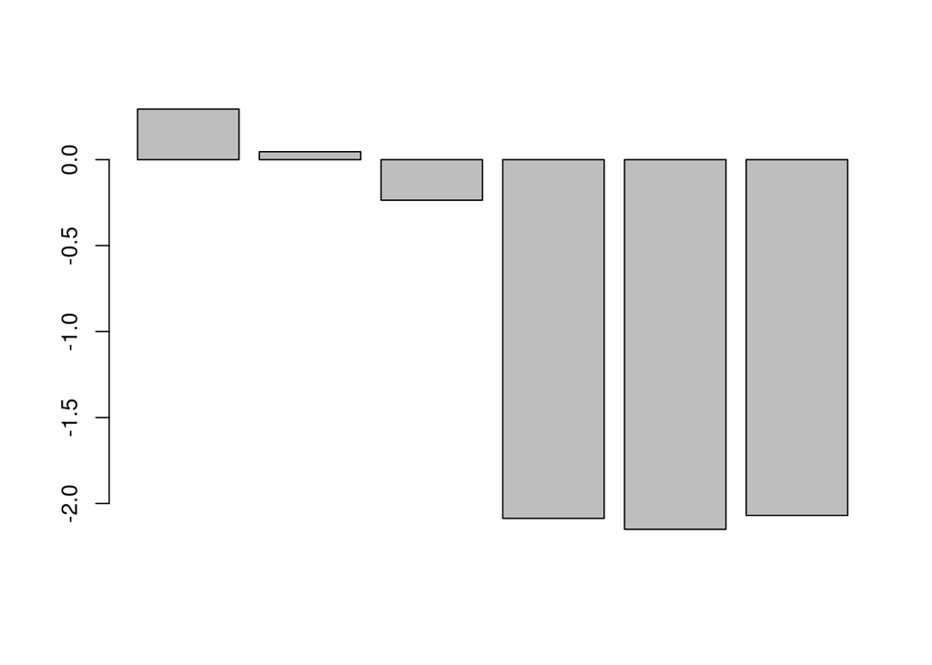

```r
barplot(y[1,])
```

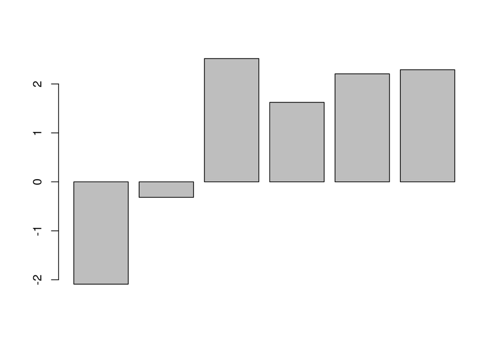

```r
barplot(y[1001,])
```

Expressed data is row 1:1000, rest is not expressed. Expression is in the last three colums consitently in one direction.

#### Question 3. What is the interpretation of the two columns of this design matrix?

```r
design <- model.matrix(~grp)
design
```

```
##   (Intercept) grp
## 1           1   0
## 2           1   0
## 3           1   0
## 4           1   1
## 5           1   1
## 6           1   1
## attr(,"assign")
## [1] 0 1
```

#### Question 4. For each row in the simulated table, calculate the classical 2-sample t-test (perhaps store the result in a vector named ‘classicalt’; see below). See ?t.test for more details about the built-in R function to do this calculation and convince yourself which arguments to use to match the t-test described in class.

```r
classicalt <- apply( y, 1, function(x){t.test(x[1:3],x[4:6], alternative="two.sided")$statistic[[1]]} )
```

#### Question 5. Add an exploratory visualization to your plots above, perhaps with a command similar to below. From this visualization, summarize any differences you see between the three statistical summaries of a change between experimental groups.

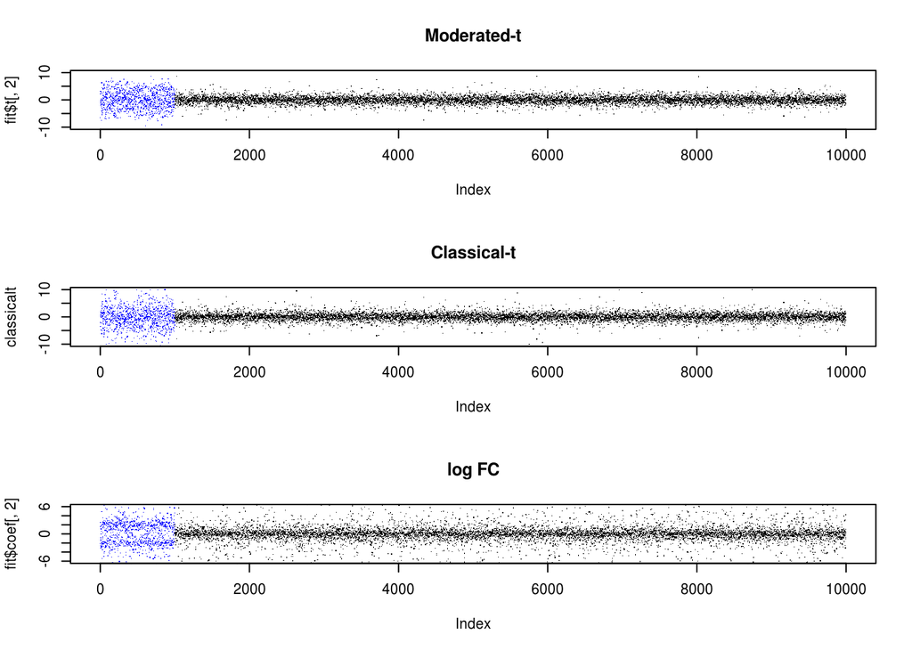

```r
cols <- rep("black",nrow(y))
cols[indD] <- "blue"

par(mfrow=c(3,1))
plot( fit$t[,2], col=cols, ylim=c(-10,10), pch=".", main="Moderated-t" )
plot( classicalt, col=cols, ylim=c(-10,10), pch=".", main="Classical-t" )
plot( fit$coef[,2], col=cols, ylim=c(-6,6), pch=".", main="log FC" )
```

Classical-t has more outliers then moderated-t especially for expressed genes log FC has even more outliers then he classical-t and spreads for the expressed genes into positive and negative instead of just increasing variance

#### Question 6. Pick a reasonable metric to compare the methods: ROC curve, false discovery plot, power versus achieved FDR. Using this metric/curve, compare the classical t-test (classicalt), the moderated t-test (fit$t) and the log-fold-change or mean difference (fit$coef). Either manually calculate and plot it or use a nice package for it (e.g., https://rocr.bioinf.mpi-sb.mpg.de/ or https://github.com/markrobinsonuzh/benchmarkR) What method(s) perform well?

```r
library(ROCR)
```

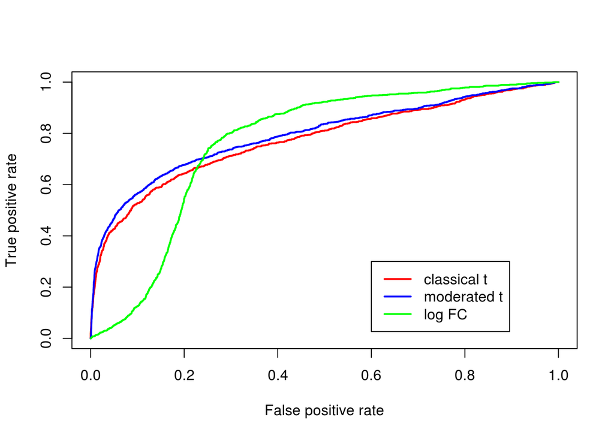

```r
labels <- c(rep(1,nGenes*pDiff),rep(0,nGenes*(1-pDiff)))
pred_classical <- prediction( abs(classicalt), labels )
perf_classical <- performance(pred_classical,"tpr","fpr")
pred_moderated <- prediction( abs(fit$t[,2]), labels )
perf_moderated <- performance(pred_moderated,"tpr","fpr")
pred_logFC <- prediction( abs(fit$coef[,2]), labels )
perf_logFC <- performance(pred_logFC,"tpr","fpr")

par(mfrow=c(1,1))
plot(perf_classical, col="red", lwd=2)
plot(perf_moderated, add=TRUE, col="blue", lwd=2)
plot(perf_logFC, add=TRUE, col="green", lwd=2)
legend(x=0.60, y=0.3, legend=c("classical t", "moderated t", "log FC"), col=c("red","blue","green"), lwd=c(2,2,2) )
```

Moderated t performs better than classical t for all FPRs. For FPRs below 0.2 it also performs better than log FC. As this is the used part the moderated t performs best for the given parameters.

#### Question 7. Explore the performance of these test statistics for a few scenarios. For example, change the sample size, the number of genes DE, magnitude of the difference, level of variability. What influence do these parameters have on the relative performance?

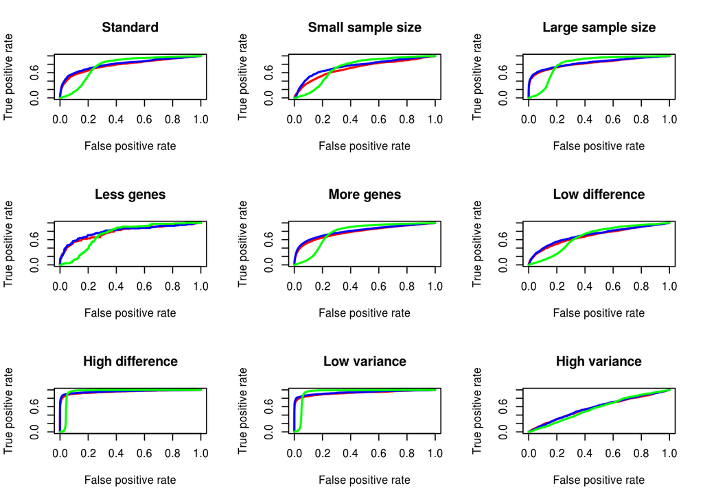

```r
plot_performance <- function(nGenes, nSamples, pDiff, trueFC, d0, s0, title){
  grp <- rep(0:1,each=nSamples/2)
  sd <- s0*sqrt(d0/rchisq(nGenes,df=d0))  # dist'n of s.d.

  y <- matrix(rnorm(nGenes*nSamples,sd=sd),
            nr=nGenes,nc=nSamples)
  indD <- 1:floor(pDiff*nGenes)
  diff <- sample(c(-1,1),max(indD),replace=TRUE)*trueFC
  y[indD,grp==1] <- y[indD,grp==1] + diff

  design <- model.matrix(~grp)

  fit <- lmFit(y,design)
  fit <- eBayes(fit)

  classicalt <- apply( y, 1, function(x){t.test(x[1:nSamples/2],x[nSamples/2+1:nSamples/2*2], alternative="two.sided")$statistic[[1]]} )

  labels <- c(rep(1,nGenes*pDiff),rep(0,nGenes*(1-pDiff)))
  pred_classical <- prediction( abs(classicalt), labels )
  perf_classical <- performance(pred_classical,"tpr","fpr")
  pred_moderated <- prediction( abs(fit$t[,2]), labels )
  perf_moderated <- performance(pred_moderated,"tpr","fpr")
  pred_logFC <- prediction( abs(fit$coef[,2]), labels )
  perf_logFC <- performance(pred_logFC,"tpr","fpr")

  plot(perf_classical, col="red", lwd=2, main=title)
  plot(perf_moderated, add=TRUE, col="blue", lwd=2)
  plot(perf_logFC, add=TRUE, col="green", lwd=2)
}

par(mfrow=c(3,3))
plot_performance(10000, 6, .1, 2, 1, 0.8, "Standard")
plot_performance(10000, 4, .1, 2, 1, 0.8, "Small sample size")
plot_performance(10000, 10, .1, 2, 1, 0.8, "Large sample size")
plot_performance(1000, 6, .1, 2, 1, 0.8, "Less genes")
plot_performance(100000, 6, .1, 2, 1, 0.8, "More genes")
plot_performance(10000, 6, .1, 1.2, 1, 0.8, "Low difference")
plot_performance(10000, 6, .1, 10, 1, 0.8, "High difference")
plot_performance(10000, 6, .1, 2, 1, 0.2, "Low variance")
plot_performance(10000, 6, .1, 2, 1, 3.2, "High variance")
```

For smaller sample size all method are worse and for large sample size all methods are better, but the moderated t is the least affected by it. The number of genes straightens out the curves and for a low number of genes the performance seems generally a bit better. The higher the genes are differentially expressed the better performs the log FC compared to the other methods. For lower and higher expression then standard the moderated t loses superiority over the classical t. A low variance has the same effect as a high difference and vice versa